# yt560_nlp

## Natural Language Processing

### Introducing External Dataset: Taylor Swift Spotify Data

```python
import pandas as pd
spotify = pd.read_csv("../../data/taylor_swift_spotify.csv",index_col = 0)
spotify.head(3)
```

|  | name | album | release_date | track_number | id | uri | acousticness | danceability | energy | instrumentalness | liveness | loudness | speechiness | tempo | valence | popularity | duration_ms |
| --- | --- | --- | --- | --- | --- | --- | --- | --- | --- | --- | --- | --- | --- | --- | --- | --- | --- |
| 0 | Welcome To New York (Taylor's Version) | 1989 (Taylor's Version) [Deluxe] | 2023-10-27 | 1 | 4WUepByoeqcedHoYhSNHRt | spotify:track:4WUepByoeqcedHoYhSNHRt | 0.009420 | 0.757 | 0.610 | 0.000037 | 0.3670 | -4.840 | 0.0327 | 116.998 | 0.685 | 80 | 212600 |
| 1 | Blank Space (Taylor's Version) | 1989 (Taylor's Version) [Deluxe] | 2023-10-27 | 2 | 0108kcWLnn2HlH2kedi1gn | spotify:track:0108kcWLnn2HlH2kedi1gn | 0.088500 | 0.733 | 0.733 | 0.000000 | 0.1680 | -5.376 | 0.0670 | 96.057 | 0.701 | 80 | 231833 |
| 2 | Style (Taylor's Version) | 1989 (Taylor's Version) [Deluxe] | 2023-10-27 | 3 | 3Vpk1hfMAQme8VJ0SNRSkd | spotify:track:3Vpk1hfMAQme8VJ0SNRSkd | 0.000421 | 0.511 | 0.822 | 0.019700 | 0.0899 | -4.785 | 0.0397 | 94.868 | 0.305 | 81 | 231000 |

```python
spotify = spotify.drop(columns = ['track_number','id','uri'])
```

```python
# Check datatypes
spotify.info()

# release date is string, not datetime type.
# no missing values in the df, and there 530 records.
```

```
<class 'pandas.core.frame.DataFrame'>
Int64Index: 530 entries, 0 to 529
Data columns (total 14 columns):
 #   Column            Non-Null Count  Dtype
---  ------            --------------  -----
 0   name              530 non-null    object
 1   album             530 non-null    object
 2   release_date      530 non-null    object
 3   acousticness      530 non-null    float64
 4   danceability      530 non-null    float64
 5   energy            530 non-null    float64
 6   instrumentalness  530 non-null    float64
 7   liveness          530 non-null    float64
 8   loudness          530 non-null    float64
 9   speechiness       530 non-null    float64
 10  tempo             530 non-null    float64
 11  valence           530 non-null    float64
 12  popularity        530 non-null    int64
 13  duration_ms       530 non-null    int64
dtypes: float64(9), int64(2), object(3)
memory usage: 62.1+ KB
```

```python
# Change datatype
spotify['release_date'] = spotify['release_date'].apply(pd.to_datetime)
spotify.info()
```

```
<class 'pandas.core.frame.DataFrame'>
Int64Index: 530 entries, 0 to 529
Data columns (total 14 columns):
 #   Column            Non-Null Count  Dtype
---  ------            --------------  -----
 0   name              530 non-null    object
 1   album             530 non-null    object
 2   release_date      530 non-null    datetime64[ns]
 3   acousticness      530 non-null    float64
 4   danceability      530 non-null    float64
 5   energy            530 non-null    float64
 6   instrumentalness  530 non-null    float64
 7   liveness          530 non-null    float64
 8   loudness          530 non-null    float64
 9   speechiness       530 non-null    float64
 10  tempo             530 non-null    float64
 11  valence           530 non-null    float64
 12  popularity        530 non-null    int64
 13  duration_ms       530 non-null    int64
dtypes: datetime64[ns](1), float64(9), int64(2), object(2)
memory usage: 62.1+ KB
```

```python
import re
# remove the albums released after the reddit data
spotify = spotify[(spotify['release_date']<'2023-03-31')]

def album_cleaning(input_string):
    input_string = re.sub(r'\([^)]*\)', '', input_string) # matches parentheses
    input_string = re.sub(r'\[[^\]]*\]', '', input_string) # matches brackets
    input_string = input_string.split(':')[0] # remove strings after colon
    input_string = input_string.strip() # remove spaces at the begining and the end of the string
    return input_string

# string cleaning on album names
spotify['album'] = spotify['album'].apply(lambda x: album_cleaning(x))

spotify.head(5)
```

|  | name | album | release_date | acousticness | danceability | energy | instrumentalness | liveness | loudness | speechiness | tempo | valence | popularity | duration_ms |
| --- | --- | --- | --- | --- | --- | --- | --- | --- | --- | --- | --- | --- | --- | --- |
| 88 | Lavender Haze | Midnights | 2022-10-22 | 0.2040 | 0.735 | 0.444 | 0.001200 | 0.1700 | -10.519 | 0.0684 | 97.038 | 0.0984 | 72 | 202395 |
| 89 | Maroon | Midnights | 2022-10-22 | 0.0593 | 0.658 | 0.378 | 0.000000 | 0.0976 | -8.300 | 0.0379 | 108.034 | 0.0382 | 71 | 218270 |
| 90 | Anti-Hero | Midnights | 2022-10-22 | 0.1330 | 0.638 | 0.634 | 0.000001 | 0.1520 | -6.582 | 0.0457 | 96.953 | 0.5190 | 72 | 200690 |
| 91 | Snow On The Beach (feat. Lana Del Rey) | Midnights | 2022-10-22 | 0.7350 | 0.659 | 0.323 | 0.003210 | 0.1160 | -13.425 | 0.0436 | 110.007 | 0.1540 | 70 | 256124 |
| 92 | You're On Your Own, Kid | Midnights | 2022-10-22 | 0.4160 | 0.694 | 0.380 | 0.000008 | 0.1260 | -10.307 | 0.0614 | 120.044 | 0.3760 | 72 | 194206 |

### The summary table for further analysis

```python
# summary on mean values of acousticness, ..., popularity, duration_ms
summary_table_mean = spotify.groupby(['album']).mean()
summary_table_mean.reset_index(inplace = True)
summary_table_mean.head(5)
```

|  | album | acousticness | danceability | energy | instrumentalness | liveness | loudness | speechiness | tempo | valence | popularity | duration_ms |
| --- | --- | --- | --- | --- | --- | --- | --- | --- | --- | --- | --- | --- |
| 0 | 1989 | 0.191166 | 0.639781 | 0.655000 | 8.077356e-04 | 0.183453 | -7.238875 | 0.129922 | 125.837156 | 0.457619 | 68.187500 | 220422.250000 |
| 1 | Fearless | 0.201353 | 0.564949 | 0.638513 | 9.976923e-07 | 0.156754 | -5.889692 | 0.036233 | 125.236641 | 0.409359 | 65.948718 | 246291.384615 |
| 2 | Fearless Platinum Edition | 0.202448 | 0.575947 | 0.601053 | 2.270000e-06 | 0.159826 | -5.708211 | 0.031905 | 123.089263 | 0.380053 | 45.947368 | 250874.789474 |
| 3 | Live From Clear Channel Stripped 2008 | 0.551250 | 0.548125 | 0.598875 | 0.000000e+00 | 0.144113 | -5.067000 | 0.045125 | 137.639000 | 0.472125 | 39.375000 | 209469.375000 |
| 4 | Lover | 0.333743 | 0.658222 | 0.545222 | 7.330572e-04 | 0.115233 | -8.013278 | 0.099117 | 119.972722 | 0.481444 | 82.611111 | 206187.833333 |

```python
summary_table_mean.to_csv("spotify_summary_table.csv",index = False)
```

```python
# from datetime import timedelta,datetime

# def ms_to_hhmmss(input_ms):
#     d = timedelta(milliseconds = input_ms) # convert milliseconds to hh:mm:ss

#     try: # case that the returning time object is in the format of hh:mm:ss.ffffff
#         hhmmss = datetime.strptime(str(d),'%H:%M:%S.%f').time().strftime('%H:%M:%S') # drop the floats
#         hhmmss = datetime.strptime(hhmmss,'%H:%M:%S').time() # get time, exclude date
#         return hhmmss

#     except: # case thet the returning time object is is the format of hh:mm:ss
#         hhmmss = datetime.strptime(str(d),'%H:%M:%S').time() # get time, exclude date
#         return hhmmss

# summary_table_mean['duration_hhmmss'] = summary_table_mean['duration_ms'].apply(lambda x: ms_to_hhmmss(x))
# summary_table_mean.drop('duration_ms',axis = 1, inplace = True)
# summary_table_mean.head(5)
```

### Install Pyspark

```python
# Setup - Run only once per Kernel App
%conda install openjdk -y

# install PySpark
%pip install pyspark==3.3.0

# restart kernel
from IPython.core.display import HTML
HTML("<script>Jupyter.notebook.kernel.restart()</script>")
```

[output not shown]

### Build Spark Session

```python
# Import pyspark and build Spark session
from pyspark.sql import SparkSession

spark = (
    SparkSession.builder.appName("PySparkApp")
    .config("spark.jars.packages", "org.apache.hadoop:hadoop-aws:3.2.2")
    .config(
        "fs.s3a.aws.credentials.provider",
        "com.amazonaws.auth.ContainerCredentialsProvider",
    )
    .getOrCreate()
)

print(spark.version)
```

```
:: loading settings :: url = jar:file:/opt/conda/lib/python3.10/site-packages/pyspark/jars/ivy-2.5.0.jar!/org/apache/ivy/core/settings/ivysettings.xml
```

[output not shown]

```
23/12/08 22:18:00 WARN NativeCodeLoader: Unable to load native-hadoop library for your platform... using builtin-java classes where applicable
```

```
Setting default log level to "WARN".
To adjust logging level use sc.setLogLevel(newLevel). For SparkR, use setLogLevel(newLevel).
```

```
23/12/08 22:18:02 WARN Utils: Service 'SparkUI' could not bind on port 4040. Attempting port 4041.
23/12/08 22:18:02 WARN Utils: Service 'SparkUI' could not bind on port 4041. Attempting port 4042.
3.3.0
```

```python
import pyspark.sql.functions as f
```

```python
submissions = spark.read.parquet("s3a://dsan-6000-group-35/submissions.parquet",header = True)
comments = spark.read.parquet("s3a://dsan-6000-group-35/comments.parquet",header = True)
```

```
23/12/08 22:18:06 WARN MetricsConfig: Cannot locate configuration: tried hadoop-metrics2-s3a-file-system.properties,hadoop-metrics2.properties
```

### Text data check

Most common words over the past 3 years

```python
import nltk
nltk.download('stopwords')
```

```
True
```

```python
import pandas as pd
from nltk.corpus import stopwords
stopwords_list = stopwords.words('english')

common_words = pd.DataFrame()

for year in [2021,2022,2023]:

    # fiter by year
    submission_year = submissions.filter(f.col('year')==year)

    # split text data into list
    text = submission_year.select(f.split(submission_year.text, " ").alias("text"))
    # explode list of words
    words = text.select(f.explode(f.col("text")).alias("word"))
    # lower case
    words_lower = words.select(f.lower(f.col("word")).alias("word_lower"))

    # remove punctuation
    words_clean = words_lower.select(f.regexp_extract(f.col("word_lower"), "[a-z]+", 0).alias("word"))

    # remove na
    words_clean = words_clean.filter(f.col("word") != "")

    words_count = (words_clean.groupby("word").count().orderBy("count", ascending=False))

    top_10 = words_count.limit(10)

    top_10 = top_10.toPandas()

    common_words[f"{year}_submissions"] =top_10['word']
```

```python
common_words
```

|  | 2021_submissions | 2022_submissions | 2023_submissions |
| --- | --- | --- | --- |
| 0 | the | the | the |
| 1 | i | i | i |
| 2 | to | to | to |
| 3 | and | and | and |
| 4 | a | a | a |
| 5 | of | of | of |
| 6 | it | it | it |
| 7 | in | in | in |
| 8 | you | is | you |
| 9 | is | you | is |

```python
for year in [2021,2022,2023]:

    # fiter by year
    comments_year = comments.filter(f.col('year')==year)

    # split text data into list
    text = comments_year.select(f.split(comments_year.body, " ").alias("text"))
    # explode list of words
    words = text.select(f.explode(f.col("text")).alias("word"))
    # lower case
    words_lower = words.select(f.lower(f.col("word")).alias("word_lower"))

    # remove punctuation
    words_clean = words_lower.select(f.regexp_extract(f.col("word_lower"), "[a-z]+", 0).alias("word"))

    # remove na
    words_clean = words_clean.filter(f.col("word") != "")

    words_count = (words_clean.groupby("word").count().orderBy("count", ascending=False))

    top_10 = words_count.limit(10)

    top_10 = top_10.toPandas()

    common_words[f"{year}_comments"] =top_10['word']
```

```python
common_words
```

|  | 2021_submissions | 2022_submissions | 2023_submissions | 2021_comments | 2022_comments | 2023_comments |
| --- | --- | --- | --- | --- | --- | --- |
| 0 | the | the | the | the | the | the |
| 1 | i | i | i | to | i | i |
| 2 | to | to | to | a | to | to |
| 3 | and | and | and | i | a | a |
| 4 | a | a | a | and | and | and |
| 5 | of | of | of | you | it | it |
| 6 | it | it | it | it | of | of |
| 7 | in | in | in | of | you | you |
| 8 | you | is | you | that | that | that |
| 9 | is | you | is | is | is | is |

```python
!pip install kaleido
```

```
  Using cached kaleido-0.2.1-py2.py3-none-manylinux1_x86_64.whl (79.9 MB)
WARNING: Running pip as the 'root' user can result in broken permissions and conflicting behaviour with the system package manager. It is recommended to use a virtual environment instead: https://pip.pypa.io/warnings/venv
```

```python
import plotly.graph_objects as go
import kaleido

fig = go.Figure(data=[go.Table(
    header = dict(values = list(common_words.columns)),
    cells = dict(values = [common_words['2021_submissions'],common_words['2022_submissions'],common_words['2023_submissions'],common_words['2021_comments'],common_words['2022_comments'],common_words['2023_comments']
            ]))])
fig.update_layout(title_text = "Table of Most Common Words over Years")

fig.write_image("yt560_common_words_table.svg")

fig.show()
```

[interactive chart not shown]

text length distribution

```python
submissions = submissions.withColumn("text_length", f.length("text"))
comments = comments.withColumn("text_length", f.length("body"))

n = 10000
submissions_sample = submissions.sample(False, n/submissions.count())
comments_sample = comments.sample(False,n/comments.count())

submissions_sample = submissions_sample.select('text_length').toPandas()
comments_sample = comments_sample.select('text_length').toPandas()
```

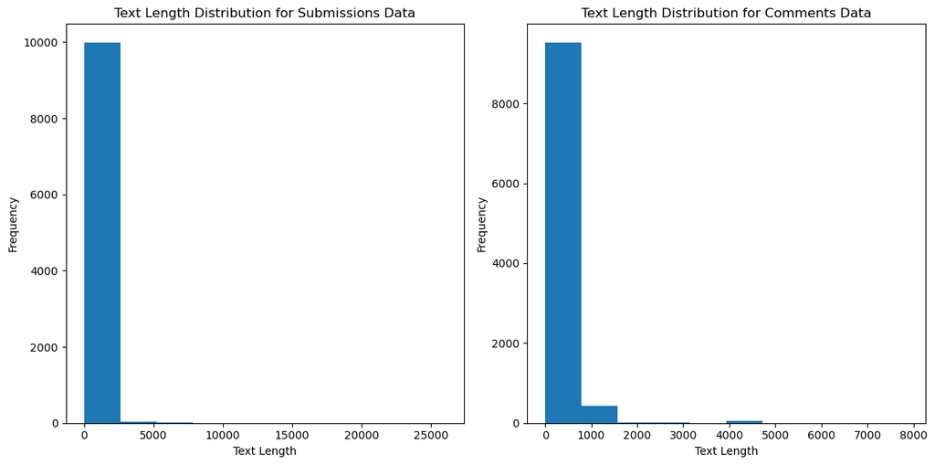

```python
import matplotlib.pyplot as plt

plt.figure(figsize=(12, 6))

# Histogram for submissions
plt.subplot(1, 2, 1)
plt.hist(submissions_sample["text_length"])
plt.title('Text Length Distribution for Submissions Data')
plt.xlabel('Text Length')
plt.ylabel('Frequency')

# Histogram for comments
plt.subplot(1, 2, 2)
plt.hist(comments_sample["text_length"])
plt.title('Text Length Distribution for Comments Data')
plt.xlabel('Text Length')
plt.ylabel('Frequency')

plt.tight_layout()

plt.savefig('text_length_distribution.png')
plt.show()
```

important words

```python
from pyspark.ml import Pipeline
from pyspark.ml.feature import CountVectorizer
from pyspark.ml.feature import HashingTF, IDF, Tokenizer, RegexTokenizer
from pyspark.ml.feature import StopWordsRemover
```

```python
submissions = submissions.withColumn("label",f.monotonically_increasing_id())
tokenizer = Tokenizer(inputCol="text", outputCol="words")

vectorizer = CountVectorizer(inputCol="words", outputCol="rawFeatures")
idf = IDF(inputCol="rawFeatures", outputCol="features", minDocFreq=2)
pipeline = Pipeline(stages=[tokenizer,vectorizer, idf])
model = pipeline.fit(submissions)
result = model.transform(submissions)
```

```
23/12/08 22:20:23 WARN DAGScheduler: Broadcasting large task binary with size 3.8 MiB
```

### Get data from different subreddit

```python
# Get data under Taylor Swift Subreddit
ts_submissions = submissions.filter("subreddit = 'TaylorSwift'")
ts_comments = comments.filter("subreddit = 'TaylorSwift'")
```

```python
# Get data under music subreddits
music_submissions = submissions.filter("subreddit != 'TaylorSwift'")
music_comments = comments.filter("subreddit != 'TaylorSwift'")
```

### Apply Regex search to get album-related text

```python
# Get unique album names, remove Taylor Swift, may cause confusing
import numpy as np
albums = spotify['album'].unique()
albums = np.delete(albums,albums == 'Taylor Swift')
albums = '|'.join(albums)
albums
```

```
'Midnights|Red|Fearless|evermore|folklore|Lover|reputation|reputation Stadium Tour Surprise Song Playlist|1989|Speak Now World Tour Live|Speak Now|Fearless Platinum Edition|Live From Clear Channel Stripped 2008'
```

```python
# apply a regex search to check if the album mentioned in the text, if matched, return the album mentioned, else return None

ts_submissions = ts_submissions.withColumn("album",f.when(f.col("text").rlike(albums),f.regexp_extract(f.col("text"),albums,0)).otherwise(None))
ts_submissions.show(5)
```

```
+----+-----+-----------+------+--------------------+-------------------+--------------------+------------+--------------+-----+-------+--------+-----+---------+
|year|month|  subreddit|    id|              author|        created_utc|                text|num_comments|num_crossposts|score|is_self|stickied|label|    album|
+----+-----+-----------+------+--------------------+-------------------+--------------------+------------+--------------+-----+-------+--------+-----+---------+
|2021|    3|TaylorSwift|m2tbw3|         storm131713|2021-03-11 15:52:54|The most connecti...|          30|             0|   43|   true|   false|   26| evermore|
|2021|    3|TaylorSwift|m2td8l|      nostalgia-geek|2021-03-11 15:54:30|I just moved and ...|           9|             0|  165|  false|   false|   29|     null|
|2021|    1|TaylorSwift|kua4oj|    franklintbassett|2021-01-10 07:37:10|If you had to say...|          19|             0|   28|   true|   false|   78|Speak Now|
|2021|    1|TaylorSwift|kuaero|stillwantthekidsmenu|2021-01-10 08:00:14|Favorite line fro...|          25|             0|   51|   true|   false|   98| evermore|
|2021|   11|TaylorSwift|qxjbc8|    ScheduleHuman326|2021-11-19 16:03:53|When you are at s...|           1|             0|    1|  false|   false|  156|     null|
+----+-----+-----------+------+--------------------+-------------------+--------------------+------------+--------------+-----+-------+--------+-----+---------+
only showing top 5 rows
```

```python
ts_comments = ts_comments.withColumn("album",f.when(f.col("body").rlike(albums),f.regexp_extract(f.col("body"),albums,0)).otherwise(None))
ts_comments.show(5)
```

```
[Stage 17:>                                                         (0 + 1) / 1]
```

```
+----+-----+-----------+-------+--------------+---------+----------+-------------------+--------------------+-----+------+----------------+---------+
|year|month|  subreddit|     id|        author|  link_id| parent_id|        created_utc|                body|score|gilded|controversiality|    album|
+----+-----+-----------+-------+--------------+---------+----------+-------------------+--------------------+-----+------+----------------+---------+
|2022|   10|TaylorSwift|irf7cfk|realscoutfinch|t3_xwui3g|t1_iracq55|2022-10-07 16:46:13|This this this! I...|    1|     0|               0|     null|
|2022|   10|TaylorSwift|irf7gn3|   dietrichs90|t3_xt3tob| t3_xt3tob|2022-10-07 16:47:05|Taylors caption t...|   21|     0|               0|Midnights|
|2022|   10|TaylorSwift|irf7jgy|  evergreenkat|t3_xxy08f| t3_xxy08f|2022-10-07 16:47:40|The whole left co...|    2|     0|               0|     null|
|2022|   10|TaylorSwift|irf7qr0|   sapphicsato|t3_xxr3aj| t3_xxr3aj|2022-10-07 16:49:08|IWAASPIWTWWGROMBF...|    1|     0|               0|     null|
|2022|   10|TaylorSwift|irf7uk8|  hannahberrie|t3_xtuyhw|t1_irc8u25|2022-10-07 16:49:54|               Whelp|    1|     0|               0|     null|
+----+-----+-----------+-------+--------------+---------+----------+-------------------+--------------------+-----+------+----------------+---------+
only showing top 5 rows
```

```python
# get non-null rows only
ts_submissions = ts_submissions.filter(f.col('album').isNotNull())
ts_comments = ts_comments.filter(f.col('album').isNotNull())
```

```python
# for other 2 subreddit data, filter the text mentioned Taylor Swift first
music_submissions = music_submissions.filter(f.col('text').rlike('\W*(Taylor Swift)\W*'))
music_comments = music_comments.filter(f.col('body').rlike('\W*(Taylor Swift)\W*'))

# Then get the album data
music_submissions = music_submissions.withColumn("album",f.when(f.col("text").rlike(albums),f.regexp_extract(f.col("text"),albums,0)).otherwise(None))


music_comments = music_comments.withColumn("album",f.when(f.col("body").rlike(albums),f.regexp_extract(f.col("body"),albums,0)).otherwise(None))

# filter the album related text

music_submissions = music_submissions.filter(f.col('album').isNotNull())
music_comments = music_comments.filter(f.col('album').isNotNull())
```

### Merge tables

```python
# Do a merge with album data and comments/submissions data

summary_table_mean = spark.createDataFrame(summary_table_mean) # pandas df to pyspark df

df1 = ts_submissions.join(summary_table_mean,'album')
df2 = ts_comments.join(summary_table_mean,'album')

# join tables

df3 = music_submissions.join(summary_table_mean,'album')
df4 = music_comments.join(summary_table_mean,'album')
```

```python
df1.cache()
df2.cache()
df3.cache()
df4.cache()
```

```
DataFrame[album: string, year: int, month: int, subreddit: string, id: string, author: string, link_id: string, parent_id: string, created_utc: timestamp, body: string, score: bigint, gilded: bigint, controversiality: bigint, acousticness: double, danceability: double, energy: double, instrumentalne…
```

### EDA for tables after merging

```python
!pip install kaleido
```

```
WARNING: Running pip as the 'root' user can result in broken permissions and conflicting behaviour with the system package manager. It is recommended to use a virtual environment instead: https://pip.pypa.io/warnings/venv
```

```python
import plotly.express as px

n = 10000
df1_sample = df1.sample(False,n/df1.count())

df1_eda = df1_sample.groupBy('album').count().join(summary_table_mean,'album').select('album','count','popularity')

# apply a scaling
maximum = df1_eda.agg({'count':'max'}).collect()[0][0]
df1_eda = df1_eda.withColumn('count_scaled',f.col('count')/maximum * 100)

df1_eda = df1_eda.withColumn("count_scaled", f.round("count_scaled", 2))\
.withColumn("popularity", f.round("popularity", 2))\
.withColumn("source",f.lit("submissions"))
```

```python
df2_sample = df2.sample(False,n/df2.count())
df2_eda = df2_sample.groupBy('album').count().join(summary_table_mean,'album').select('album','count','popularity')

# apply a scaling
maximum = df2_eda.agg({'count':'max'}).collect()[0][0]
df2_eda = df2_eda.withColumn('count_scaled',f.col('count')/maximum * 100)

df2_eda = df2_eda.withColumn("count_scaled", f.round("count_scaled", 2)).withColumn("popularity", f.round("popularity", 2)).withColumn("source",f.lit("comments"))
```

```python
df1_eda = df1_eda.toPandas()
df2_eda = df2_eda.toPandas()
eda_1 = pd.concat([df1_eda,df2_eda])
eda_1
```

|  | album | count | popularity | count_scaled | source |
| --- | --- | --- | --- | --- | --- |
| 0 | 1989 | 1107 | 68.19 | 59.68 | submissions |
| 1 | Fearless | 1206 | 65.95 | 65.01 | submissions |
| 2 | Lover | 1174 | 82.61 | 63.29 | submissions |
| 3 | Midnights | 1855 | 76.36 | 100.00 | submissions |
| 4 | Red | 1769 | 59.75 | 95.36 | submissions |
| 5 | Speak Now | 706 | 55.59 | 38.06 | submissions |
| 6 | Speak Now World Tour Live | 8 | 49.00 | 0.43 | submissions |
| 7 | evermore | 730 | 73.34 | 39.35 | submissions |
| 8 | folklore | 958 | 66.10 | 51.64 | submissions |
| 9 | reputation | 489 | 82.93 | 26.36 | submissions |
| 0 | 1989 | 1662 | 68.19 | 87.75 | comments |
| 1 | Fearless | 1003 | 65.95 | 52.96 | comments |
| 2 | Lover | 1451 | 82.61 | 76.61 | comments |
| 3 | Midnights | 674 | 76.36 | 35.59 | comments |
| 4 | Red | 1894 | 59.75 | 100.00 | comments |
| 5 | Speak Now | 762 | 55.59 | 40.23 | comments |
| 6 | evermore | 935 | 73.34 | 49.37 | comments |
| 7 | folklore | 1082 | 66.10 | 57.13 | comments |
| 8 | reputation | 667 | 82.93 | 35.22 | comments |

```python
eda_1.to_csv("album_count_and_popularity.csv",index = False)
```

```python
import kaleido
import plotly.graph_objects as go
from plotly.subplots import make_subplots


fig = px.bar(eda_1,
             x = 'album',
             y = ['count_scaled','popularity'],
             facet_row = 'source',
             title='Grouped Bar Plot of Scaled Album Count and Popularity',
             labels = {'album':'Albums','value':"",'variable':""},
             text_auto = '.2f',
             template = 'plotly_white',
             barmode = 'group',
             width = 1000,
             height = 600)


fig.update_layout(bargap = 0.5)
fig.update_traces(textposition = 'outside')
fig.update_xaxes(tickfont = dict(size = 10),tickangle = 10)
fig.update_yaxes(range=[0,110])

#fig.write_image("yt560_album_count_and_popularity_1.svg")
fig.show()
```

[interactive chart not shown]

```python
df3_eda = df3.groupBy('album').count().join(summary_table_mean,'album').select('album','count','popularity')

# apply a scaling
maximum = df3_eda.agg({'count':'max'}).collect()[0][0]
df3_eda = df3_eda.withColumn('count_scaled_submissions',f.col('count')/maximum * 100).withColumnRenamed('count','count_submissions')

df3_eda = df3_eda.withColumn("count_scaled_submissions", f.round("count_scaled_submissions", 2))\
.withColumn("popularity", f.round("popularity", 2))\
.select('album','count_scaled_submissions','count_submissions','popularity')

#df4_sample = df4.sample(False,n/df4.count())

df4_eda = df4.groupBy('album').count().join(summary_table_mean,'album').select('album','count','popularity')

# apply a scaling
maximum = df4_eda.agg({'count':'max'}).collect()[0][0]
df4_eda = df4_eda.withColumn('count_scaled_comments',f.col('count')/maximum * 100).withColumnRenamed('count','count_comments')

df4_eda = df4_eda.withColumn("count_scaled_comments", f.round("count_scaled_comments", 2))\
.withColumn("popularity", f.round("popularity", 2))\
.select('album','count_scaled_comments','count_comments','popularity')

eda_2 = df3_eda.join(df4_eda,['album','popularity'])
eda_2 = eda_2.toPandas()
```

```python
eda2_table = eda_2[['album','popularity','count_submissions','count_comments']]
eda2_table
```

|  | album | popularity | count_submissions | count_comments |
| --- | --- | --- | --- | --- |
| 0 | 1989 | 68.19 | 8 | 169 |
| 1 | Fearless | 65.95 | 20 | 33 |
| 2 | Lover | 82.61 | 9 | 64 |
| 3 | Midnights | 76.36 | 34 | 66 |
| 4 | Red | 59.75 | 37 | 182 |
| 5 | Speak Now | 55.59 | 1 | 24 |
| 6 | Speak Now World Tour Live | 49.00 | 1 | 1 |
| 7 | evermore | 73.34 | 7 | 18 |
| 8 | folklore | 66.10 | 9 | 68 |
| 9 | reputation | 82.93 | 2 | 21 |

```python
eda2_table.to_csv('album_count_popularity_table_music_subs.csv')
```

```python
fig = px.bar(eda_2,
             x = 'album',
             y = ['count_scaled_submissions','count_scaled_comments','popularity'],
             title='Grouped Bar Plot of Scaled Album Count and Popularity <br><sup>From Both comments data and submissions data under music-related subreddit</sup>',
             labels = {'album':'Albums','value':"",'variable':""},
             text_auto = '.2f',
             template = 'plotly_white',
             barmode = 'group',
             width = 1000,
             height = 450)


fig.update_layout(bargap = 0.5)
fig.update_traces(textposition = 'outside',textfont_size = 300)
fig.update_xaxes(tickfont = dict(size = 10),tickangle = 10)
fig.update_yaxes(range=[0,110])

#fig.write_image("yt560_album_count_and_popularity_2.svg")
fig.show()
```

[interactive chart not shown]

### Sentiment Analysis on Text Data

```python
# Setup - Run only once per Kernel App
%conda install openjdk -y

# install PySpark
%pip install pyspark==3.3.0

# install spark-nlp
%pip install spark-nlp==5.1.3

# restart kernel
from IPython.core.display import HTML
HTML("<script>Jupyter.notebook.kernel.restart()</script>")
```

[output not shown]

```python
import json
import sparknlp
import numpy as np
import pandas as pd
from sparknlp.base import *
from pyspark.ml import Pipeline
from sparknlp.annotator import *
import pyspark.sql.functions as f
from pyspark.sql import SparkSession
from sparknlp.pretrained import PretrainedPipeline
```

```python
# Import pyspark and build Spark session
spark = SparkSession.builder \
    .appName("Spark NLP")\
    .master("local[*]")\
    .config("spark.driver.memory","16G")\
    .config("spark.driver.maxResultSize", "0") \
    .config("spark.kryoserializer.buffer.max", "2000M")\
    .config("spark.jars.packages", "com.johnsnowlabs.nlp:spark-nlp_2.12:5.1.3,org.apache.hadoop:hadoop-aws:3.2.2")\
    .config("fs.s3a.aws.credentials.provider","com.amazonaws.auth.ContainerCredentialsProvider")\
    .getOrCreate()
```

```
:: loading settings :: url = jar:file:/opt/conda/lib/python3.10/site-packages/pyspark/jars/ivy-2.5.0.jar!/org/apache/ivy/core/settings/ivysettings.xml
```

[output not shown]

[output cut: 116 more lines]

[output not shown]

```
23/11/20 11:03:35 WARN NativeCodeLoader: Unable to load native-hadoop library for your platform... using builtin-java classes where applicable
```

```
Setting default log level to "WARN".
To adjust logging level use sc.setLogLevel(newLevel). For SparkR, use setLogLevel(newLevel).
```

```python
print(f"Spark version: {spark.version}")
print(f"sparknlp version: {sparknlp.version()}")
```

```
Spark version: 3.3.0
sparknlp version: 5.1.3
```

```python
submissions = spark.read.parquet("s3a://dsan-6000-group-35/submissions.parquet",header = True)
comments = spark.read.parquet("s3a://dsan-6000-group-35/comments.parquet",header = True)
```

```
23/11/20 07:51:28 WARN MetricsConfig: Cannot locate configuration: tried hadoop-metrics2-s3a-file-system.properties,hadoop-metrics2.properties
```

### Work on submissions data

```python
submissions_sample = submissions.limit(10)
```

```python
from sparknlp.base import *
from sparknlp.annotator import *
import pyspark.sql.functions as f
from pyspark.ml import Pipeline
from sparknlp.pretrained import PretrainedPipeline
from pyspark.ml.feature import StopWordsRemover

default_stopwords = StopWordsRemover.loadDefaultStopWords('english')

# 1. raw text to document
document_assembler = DocumentAssembler()\
    .setInputCol("text")\
    .setOutputCol("document")

# 2. get the tokens of the text
tokenizer = Tokenizer()\
    .setInputCols(["document"])\
    .setOutputCol("token")

# 3. normalizer
normalizer = Normalizer()\
    .setInputCols(["token"])\
    .setOutputCol("normalized")\
    .setLowercase(True)\
    .setCleanupPatterns(["""[^\w\d\s]"""])

# 4. stemmer
stemmer = Stemmer()\
    .setInputCols(["normalized"])\
    .setOutputCol("stem")

# 5. lemmatizer
lemmatizer = LemmatizerModel.pretrained() \
    .setInputCols(["stem"]) \
    .setOutputCol("lemma")

# 6. remove stop words
stopwords_cleaner = StopWordsCleaner()\
    .setInputCols(["lemma"])\
    .setOutputCol("cleanedLemma")\
    .setStopWords(default_stopwords)\
    .setCaseSensitive(False)

# 6. apply a pre trained model
vivekn =  ViveknSentimentModel.pretrained()\
    .setInputCols(["document", "cleanedLemma"])\
    .setOutputCol("result_sentiment")

# 7. remove intermediate outputs, keep sentiment only
finisher = Finisher() \
.setInputCols(["result_sentiment"]) \
.setOutputCols("sentiment")

# Define the pipeline for submissions
nlp_pipeline = Pipeline(stages=[
    document_assembler,
    tokenizer,
    normalizer,
    stemmer,
    lemmatizer,
    stopwords_cleaner,
    vivekn,
    finisher
])
```

```
lemma_antbnc download started this may take some time.
```

```
[Stage 11:>                                                         (0 + 4) / 4]
```

```
Approximate size to download 907.6 KB
[OK!]
sentiment_vivekn download started this may take some time.
Approximate size to download 873.6 KB
[OK!]
```

```python
# test on sample data
model = nlp_pipeline.fit(submissions_sample)
result = model.transform(submissions_sample)
result.printSchema()
```

```
WARNING: An illegal reflective access operation has occurred
WARNING: Illegal reflective access by org.apache.spark.util.SizeEstimator$ (file:/opt/conda/lib/python3.10/site-packages/pyspark/jars/spark-core_2.12-3.3.0.jar) to field java.util.regex.Pattern.pattern
WARNING: Please consider reporting this to the maintainers of org.apache.spark.util.SizeEstimator$
WARNING: Use --illegal-access=warn to enable warnings of further illegal reflective access operations
WARNING: All illegal access operations will be denied in a future release
```

```
root
 |-- year: integer (nullable = true)
 |-- month: integer (nullable = true)
 |-- subreddit: string (nullable = true)
 |-- id: string (nullable = true)
 |-- author: string (nullable = true)
 |-- created_utc: timestamp (nullable = true)
 |-- text: string (nullable = true)
 |-- num_comments: long (nullable = true)
 |-- num_crossposts: long (nullable = true)
 |-- score: long (nullable = true)
 |-- is_self: boolean (nullable = true)
 |-- stickied: boolean (nullable = true)
 |-- sentiment: array (nullable = true)
 |    |-- element: string (containsNull = true)
```

```python
# contains na values
result.select('sentiment').show(10)
```

```
[Stage 10:>                                                         (0 + 1) / 1]
```

```
+----------+
| sentiment|
+----------+
|[positive]|
|[positive]|
|[negative]|
|[negative]|
|      [na]|
|[negative]|
|[negative]|
|      [na]|
|[negative]|
|[negative]|
+----------+
```

```python
# apply model on submissions data
empty_df = spark.createDataFrame([['']]).toDF("text")
model = nlp_pipeline.fit(empty_df)
submissions_result = model.transform(submissions)

# remove empty returns
submissions_result = submissions_result.filter(f.size(f.col('sentiment')) > 0 )

# convert final outcome from list of elements to string
submissions_result = submissions_result.withColumn("sentiment", f.regexp_replace(f.concat_ws("", f.col("sentiment")), "[\\[\\]]", ""))

# remove nas
submissions_result = submissions_result.filter(f.col('sentiment')!= 'na')
submissions_result.groupBy('sentiment').count().show()
```

```
[Stage 15:===========================================>              (3 + 1) / 4]
```

```
+---------+------+
|sentiment| count|
+---------+------+
| positive|169538|
| negative|121565|
+---------+------+
```

```python
submissions_result.show(5)
```

```
+----+-----+---------+------+--------------------+-------------------+--------------------+------------+--------------+-----+-------+--------+---------+
|year|month|subreddit|    id|              author|        created_utc|                text|num_comments|num_crossposts|score|is_self|stickied|sentiment|
+----+-----+---------+------+--------------------+-------------------+--------------------+------------+--------------+-----+-------+--------+---------+
|2021|    6|    Music|o2omjb|     the_dionysian_1|2021-06-18 13:03:18|Bo Burnham - Welc...|        1656|             2|20968|  false|   false| positive|
|2021|    6|    Music|o2onm6|       Seismic_Noise|2021-06-18 13:04:51|LIQUERUS Resident...|           0|             0|    2|  false|   false| positive|
|2021|    6|    Music|o2oop3|SteveNewmanGuitarist|2021-06-18 13:06:31|Steve Newman - Rd...|           0|             0|    1|  false|   false| negative|
|2021|    6|    Music|o2op0p|         Zoinksbeats|2021-06-18 13:07:01|(FREE) Playboi Ca...|           1|             0|    1|  false|   false| negative|
|2021|    6|    Music|o2org3|  BiscuitsAndTeaCups|2021-06-18 13:10:43|Biscuit Sundown -...|           0|             0|    1|  false|   false| negative|
+----+-----+---------+------+--------------------+-------------------+--------------------+------------+--------------+-----+-------+--------+---------+
only showing top 5 rows
```

### Work on comments data

```python
document_assembler = DocumentAssembler()\
    .setInputCol("body")\
    .setOutputCol("document")

nlp_pipeline = Pipeline(stages=[
    document_assembler,
    tokenizer,
    normalizer,
    stemmer,
    lemmatizer,
    stopwords_cleaner,
    vivekn,
    finisher
])

empty_df = spark.createDataFrame([['']]).toDF("body")
model = nlp_pipeline.fit(empty_df)
comments_result = model.transform(comments)

comments_result = comments_result.filter(f.size(f.col('sentiment')) > 0 )

# convert final outcome from list of elements to string
comments_result = comments_result.withColumn("sentiment", f.regexp_replace(f.concat_ws("", f.col("sentiment")), "[\\[\\]]", ""))
comments_result = comments_result.filter(f.col('sentiment')!= 'na')
```

```python
comments_result.show(20)
```

```
[Stage 18:>                                                         (0 + 1) / 1]
```

```
+----+-----+-----------+-------+--------------------+---------+----------+-------------------+--------------------+-----+------+----------------+---------+
|year|month|  subreddit|     id|              author|  link_id| parent_id|        created_utc|                body|score|gilded|controversiality|sentiment|
+----+-----+-----------+-------+--------------------+---------+----------+-------------------+--------------------+-----+------+----------------+---------+
|2022|   10|TaylorSwift|irf7cfk|      realscoutfinch|t3_xwui3g|t1_iracq55|2022-10-07 16:46:13|This this this! I...|    1|     0|               0| positive|
|2022|   10|      Music|irf7cqw|          Alouitious|t3_xxz930|t1_irf6yfd|2022-10-07 16:46:17|4. Once you've bu...|    4|     0|               0| negative|
|2022|   10|      Music|irf7dpm|       ToastedSimian|t3_xy1kr4|t1_ireuzta|2022-10-07 16:46:29|Sadly, I'm a work...|    1|     0|               0| positive|
|2022|   10|      Music|irf7drt|          tommykiddo|t3_xxz930|t1_irf39w8|2022-10-07 16:46:30|Ultimate Guitar h...|    3|     0|               0| negative|
|2022|   10|      Music|irf7ghz|            monkee67|t3_xy0jgc| t3_xy0jgc|2022-10-07 16:47:03|MEH  \n\nBTW this...|   -2|     0|               1| negative|
|2022|   10|TaylorSwift|irf7gn3|         dietrichs90|t3_xt3tob| t3_xt3tob|2022-10-07 16:47:05|Taylors caption t...|   21|     0|               0| positive|
|2022|   10|      Music|irf7jai|          dogsarefun|t3_xxrwic|t1_irdprwc|2022-10-07 16:47:38|Also, Aesop Rock ...|    0|     0|               0| negative|
|2022|   10|TaylorSwift|irf7jgy|        evergreenkat|t3_xxy08f| t3_xxy08f|2022-10-07 16:47:40|The whole left co...|    2|     0|               0| negative|
|2022|   10|      Music|irf7txv|             Kidspud|t3_xy0jgc|t1_irepwh7|2022-10-07 16:49:47|I agree 100%. I f...|   17|     0|               0| negative|
|2022|   10|TaylorSwift|irf7vm7|       AutoModerator|t3_xy42ef| t3_xy42ef|2022-10-07 16:50:07|**All posts are a...|    1|     0|               0| positive|
|2022|   10|      Music|irf813a|         okdude23232|t3_91z3j5|t1_ino5ijx|2022-10-07 16:51:15|people who call t...|    1|     0|               0| positive|
|2022|   10|TaylorSwift|irf8464|              vlarek|t3_xt3tob|t1_irf7rn4|2022-10-07 16:51:53|Grey's aired last...|    7|     0|               0| positive|
|2022|   10|TaylorSwift|irf86gd|         robynnc1290|t3_xt3tob|t1_irf7gn3|2022-10-07 16:52:22|I think there’s s...|    8|     0|               0| negative|
|2022|   10|      Music|irf86z7|          -n0isyb0y-|t3_lzmzv9| t3_lzmzv9|2022-10-07 16:52:29|I am not sure but...|    1|     0|               0| positive|
|2022|   10|      Music|irf8aqn|     drewisawesome14|t3_xx7syx|t1_irdn777|2022-10-07 16:53:16|That’s interestin...|    1|     0|               0| negative|
|2022|   10|      Music|irf8bch|  JoeCorsonStageDeli|t3_xy0jgc| t3_xy0jgc|2022-10-07 16:53:23|Used to really re...|    7|     0|               0| positive|
|2022|   10|TaylorSwift|irf8hei|               lom41|t3_xxy08f|t1_irelrrs|2022-10-07 16:54:38|I love the anti-h...|    5|     0|               0| positive|
|2022|   10|TaylorSwift|irf8ijo|        indievibes23|t3_xxt7wd| t3_xxt7wd|2022-10-07 16:54:52|I’M SO EXCITED! I...|    3|     0|               0| negative|
|2022|   10|TaylorSwift|irf8j4f|OnlyTSwiftSubreddits|t3_xt3tob|t1_ireyy6q|2022-10-07 16:54:59|She's been really...|    2|     0|               0| positive|
|2022|   10|      Music|irf8m64|    Mind-Reflections|t3_xy0jgc| t3_xy0jgc|2022-10-07 16:55:38|This whole album ...|    1|     0|               0| positive|
+----+-----+-----------+-------+--------------------+---------+----------+-------------------+--------------------+-----+------+----------------+---------+
only showing top 20 rows
```

```python
# save df with sentiment results
bucket = 'dsan-6000-group-35'
submissions_result.write.mode('overwrite').parquet(f"s3a://{bucket}/submissions_with_sentiment.parquet")
comments_result.write.mode('overwrite').parquet(f"s3a://{bucket}/comments_with_sentiment.parquet")
```

```python
# read comments & submissions with sentiment data
bucket = 'dsan-6000-group-35'
submissions = spark.read.parquet(f"s3a://{bucket}/submissions_with_sentiment.parquet")
comments = spark.read.parquet(f"s3a://{bucket}/comments_with_sentiment.parquet")
```

```python
submissions_result_summary_table = submissions.groupBy('sentiment').count()
submissions_result_summary_table.show()
```

```
[Stage 85:>                                                         (0 + 2) / 2]
```

```
+---------+------+
|sentiment| count|
+---------+------+
| positive|169538|
| negative|121565|
+---------+------+
```

```python
comments_result_summary_table = comments.groupBy('sentiment').count()
comments_result_summary_table.show()
```

```
[Stage 88:==================================================>       (7 + 1) / 8]
```

```
+---------+-------+
|sentiment|  count|
+---------+-------+
| positive|2892614|
| negative|1963272|
+---------+-------+
```

```python
submissions.show(5)
```

```
+----+-----+---------+------+--------------------+-------------------+--------------------+------------+--------------+-----+-------+--------+---------+
|year|month|subreddit|    id|              author|        created_utc|                text|num_comments|num_crossposts|score|is_self|stickied|sentiment|
+----+-----+---------+------+--------------------+-------------------+--------------------+------------+--------------+-----+-------+--------+---------+
|2021|    6|    Music|o2omjb|     the_dionysian_1|2021-06-18 13:03:18|Bo Burnham - Welc...|        1656|             2|20968|  false|   false| positive|
|2021|    6|    Music|o2onm6|       Seismic_Noise|2021-06-18 13:04:51|LIQUERUS Resident...|           0|             0|    2|  false|   false| positive|
|2021|    6|    Music|o2oop3|SteveNewmanGuitarist|2021-06-18 13:06:31|Steve Newman - Rd...|           0|             0|    1|  false|   false| negative|
|2021|    6|    Music|o2op0p|         Zoinksbeats|2021-06-18 13:07:01|(FREE) Playboi Ca...|           1|             0|    1|  false|   false| negative|
|2021|    6|    Music|o2org3|  BiscuitsAndTeaCups|2021-06-18 13:10:43|Biscuit Sundown -...|           0|             0|    1|  false|   false| negative|
+----+-----+---------+------+--------------------+-------------------+--------------------+------------+--------------+-----+-------+--------+---------+
only showing top 5 rows
```

### Sentiment changes over time

```python
submissions_grouped = submissions.groupBy('year','month','sentiment').count()
submissions_grouped = submissions_grouped.groupBy('year', 'month').pivot('sentiment').agg({'count': 'sum'})
submissions_grouped.show()
```

```
[Stage 99:>                                                         (0 + 2) / 2]
```

```
+----+-----+--------+--------+
|year|month|negative|positive|
+----+-----+--------+--------+
|2022|   10|    5001|    6790|
|2021|    8|    3994|    5650|
|2021|    6|    5009|    6943|
|2021|    5|    6113|    7996|
|2021|   10|    3436|    5370|
|2022|    2|    3568|    5120|
|2022|    7|    4002|    5682|
|2021|   11|    3904|    6175|
|2021|    9|    3585|    5440|
|2022|   11|    4664|    6475|
|2022|    3|    3996|    5612|
|2023|    3|    4439|    6501|
|2021|   12|    3766|    5750|
|2021|    7|    4079|    5951|
|2023|    2|    3922|    5639|
|2021|    3|    6208|    8088|
|2021|    2|    6041|    8183|
|2022|    1|    3888|    6066|
|2022|    5|    3881|    5420|
|2021|    1|    7401|    8930|
+----+-----+--------+--------+
only showing top 20 rows
```

```python
!pip install kaleido
```

```
  Using cached kaleido-0.2.1-py2.py3-none-manylinux1_x86_64.whl (79.9 MB)
WARNING: Running pip as the 'root' user can result in broken permissions and conflicting behaviour with the system package manager. It is recommended to use a virtual environment instead: https://pip.pypa.io/warnings/venv
```

```python
df = submissions_grouped.toPandas()
df['date'] = pd.to_datetime(df[['year', 'month']].assign(DAY=1))
```

```python
df.to_csv("submissions_sentiment_over_time.csv",index = False)
```

```python
import plotly.express as px

fig = px.bar(df,
             x='date',
             y=['positive', 'negative'],
             title='Sentiment Over Time for Submissions data',
             labels={'year_month': 'Year-Month', 'value': 'Count', 'variable': 'Sentiment'},
             category_orders={'sentiment': ['positive', 'negative']},
             height=500,
             template = 'plotly_white')
fig.update_layout(bargap = 0.2)
fig.update_xaxes(tickfont = dict(size = 9))

#fig.write_image("yt560_sentiment_over_time_1.svg")

fig.show()
```

[interactive chart not shown]

```python
comments_grouped = comments.groupBy('year','month','sentiment').count()
comments_grouped = comments_grouped.groupBy('year', 'month').pivot('sentiment').agg({'count': 'sum'})

df = comments_grouped.toPandas()
df['date'] = pd.to_datetime(df[['year', 'month']].assign(DAY=1))
df.to_csv("comments_sentiment_over_time.csv",index = False)

import plotly.express as px
fig = px.bar(df,
             x='date',
             y=['positive', 'negative'],
             title='Sentiment Over Time for Comments data',
             labels={'year_month': 'Year-Month', 'value': 'Count', 'variable': 'Sentiment'},
             category_orders={'sentiment': ['positive', 'negative']},
             height=500,
             template = 'plotly_white')
fig.update_layout(bargap = 0.2)
fig.update_xaxes(tickfont = dict(size = 9))

#fig.write_image("yt560_sentiment_over_time_2.svg")

fig.show()
```

[interactive chart not shown]

```python
import numpy as np
albums = spotify['album'].unique()
albums = np.delete(albums,albums == 'Taylor Swift')
albums = '|'.join(albums)
albums


submissions = submissions.withColumn("album",f.when(f.col("text").rlike(albums),f.regexp_extract(f.col("text"),albums,0)).otherwise(None))
comments = comments.withColumn("album",f.when(f.col("body").rlike(albums),f.regexp_extract(f.col("body"),albums,0)).otherwise(None))

submissions = submissions.filter("subreddit = 'TaylorSwift'")
comments = comments.filter("subreddit = 'TaylorSwift'")

submissions = submissions.filter(f.col('album').isNotNull())
comments = comments.filter(f.col('album').isNotNull())

summary_table_mean = spark.createDataFrame(summary_table_mean) # pandas df to pyspark df

submissions_data = submissions.join(summary_table_mean,'album')
comments_data = comments.join(summary_table_mean,'album')

submissions_data = submissions_data.select('sentiment','album','popularity','energy','valence')
comments_data = comments_data.select('sentiment','album','popularity','energy','valence')
```

```python
from sklearn.preprocessing import MinMaxScaler
df1 = submissions_data.groupBy('sentiment','album','popularity','energy','valence').count()
df1 = df1.toPandas()
scaler = MinMaxScaler()
df1['scaled_count'] = scaler.fit_transform(df1[['count']])
df1['popularity'] = df1['popularity']/100
```

```python
df1
```

|  | sentiment | album | popularity | energy | valence | count | scaled_count |
| --- | --- | --- | --- | --- | --- | --- | --- |
| 0 | negative | 1989 | 0.681875 | 0.655000 | 0.457619 | 327 | 0.268272 |
| 1 | positive | 1989 | 0.681875 | 0.655000 | 0.457619 | 707 | 0.583887 |
| 2 | negative | Fearless | 0.659487 | 0.638513 | 0.409359 | 284 | 0.232558 |
| 3 | positive | Fearless | 0.659487 | 0.638513 | 0.409359 | 870 | 0.719269 |
| 4 | positive | Lover | 0.826111 | 0.545222 | 0.481444 | 742 | 0.612957 |
| 5 | negative | Lover | 0.826111 | 0.545222 | 0.481444 | 307 | 0.251661 |
| 6 | positive | Midnights | 0.763636 | 0.435000 | 0.259288 | 1014 | 0.838870 |
| 7 | negative | Midnights | 0.763636 | 0.435000 | 0.259288 | 602 | 0.496678 |
| 8 | positive | Red | 0.597500 | 0.599074 | 0.455724 | 1208 | 1.000000 |
| 9 | negative | Red | 0.597500 | 0.599074 | 0.455724 | 482 | 0.397010 |
| 10 | negative | Speak Now | 0.555882 | 0.654235 | 0.418324 | 220 | 0.179402 |
| 11 | positive | Speak Now | 0.555882 | 0.654235 | 0.418324 | 445 | 0.366279 |
| 12 | negative | Speak Now World Tour Live | 0.490000 | 0.650250 | 0.290250 | 4 | 0.000000 |
| 13 | positive | Speak Now World Tour Live | 0.490000 | 0.650250 | 0.290250 | 4 | 0.000000 |
| 14 | positive | evermore | 0.733437 | 0.492781 | 0.427469 | 474 | 0.390365 |
| 15 | negative | evermore | 0.733437 | 0.492781 | 0.427469 | 196 | 0.159468 |
| 16 | positive | folklore | 0.661045 | 0.396507 | 0.354090 | 632 | 0.521595 |
| 17 | negative | folklore | 0.661045 | 0.396507 | 0.354090 | 232 | 0.189369 |
| 18 | positive | reputation | 0.829333 | 0.582867 | 0.293400 | 306 | 0.250831 |
| 19 | negative | reputation | 0.829333 | 0.582867 | 0.293400 | 144 | 0.116279 |

```python
df1.to_csv("album_sentiment_table.csv",index = False)
```

```python
import plotly.express as px
import plotly.graph_objects as go
import kaleido

#df1 = df1.toPandas()
x = df1['album'].unique()
fig = go.Figure(data = [
    go.Bar(name = 'negative',x=df1['album'].unique(),y=df1[df1['sentiment']=='negative']['scaled_count'],marker_color = 'lightslategrey'),
    go.Bar(name = 'positive',x=df1['album'].unique(),y=df1[df1['sentiment']=='positive']['scaled_count'],marker_color='crimson')
])

fig.add_trace(go.Scatter(x=df1['album'].unique(), y=df1[df1['sentiment']=='positive']['popularity'], mode='lines', name='Popularity', line=dict(color='green')))
fig.add_trace(go.Scatter(x=df1['album'].unique(), y=df1[df1['sentiment']=='positive']['energy'], mode='lines', name='Energy', line=dict(color='orange')))
fig.add_trace(go.Scatter(x=df1['album'].unique(), y=df1[df1['sentiment']=='positive']['valence'], mode='lines', name='Valence',line=dict(color='purple')))

fig.update_layout(barmode='group', title='Bar plot with album sentiment and popularity/energy/valence',
                  xaxis_title='Albums', yaxis_title='Scaled Count / Values',
                  height = 600,
                  width = 1000)

#fig.write_image("yt560_album_sentiment_and_popularity_1.svg")
fig.show()
```

[interactive chart not shown]

```python
df2 = comments_data.groupBy('sentiment','album','popularity','energy','valence').count()
df2 = df2.toPandas()
scaler = MinMaxScaler()
df2['scaled_count'] = scaler.fit_transform(df2[['count']])
df2['popularity'] = df2['popularity']/100
df2.to_csv("album_sentiment_table_comments.csv",index = False)


x = df2['album'].unique()
neg_data = df2[df2['sentiment']=='negative']
pos_data = df2[df2['sentiment']=='positive']

fig = go.Figure(data = [
    go.Bar(name = 'negative',x=x,y=neg_data['scaled_count'],marker_color ='lightslategrey'),
    go.Bar(name = 'positive',x=x,y=pos_data['scaled_count'],marker_color='crimson')
])

fig.add_trace(go.Scatter(x=x, y=pos_data['popularity'], mode='lines', name='Popularity', line=dict(color='green')))
fig.add_trace(go.Scatter(x=x, y=pos_data['energy'], mode='lines', name='Energy', line=dict(color='orange')))
fig.add_trace(go.Scatter(x=x, y=pos_data['valence'], mode='lines', name='Valence',line=dict(color='purple')))

fig.update_layout(barmode='group', title='Bar plot with album sentiment and popularity/energy/valence',
                  xaxis_title='Albums', yaxis_title='Scaled Count / Values',
                  height = 600,
                  width = 1000)

#fig.write_image("yt560_album_sentiment_and_popularity_2.svg")
fig.show()
```

[interactive chart not shown]

```python
import plotly.graph_objects as go
import pandas as pd
tb = pd.read_csv("../../data/csv/nlp/yt560_popularity_table.csv",index_col = 0)
fig = go.Figure(data=[go.Table(
    header = dict(values = list(tb.columns)),
    cells = dict(values = [tb.album,tb.popularity,tb.count_submissions,tb.count_comments])
            )])
fig.update_layout(height = 450,title_text = "Album popularity and count table from music-related subreddit")
#fig.write_image("yt560_popularity_table.svg")
fig.show()
```

[interactive chart not shown]

```python
eda_1.to_csv("yt560_popularity_table_2.csv")
```

```python
eda_1 = pd.read_csv("../../data/csv/nlp/yt560_popularity_table_2.csv",index_col = 0)
eda_1 = eda_1.drop(columns = ['count_scaled'])

fig = go.Figure(data=[go.Table(
    header = dict(values = list(eda_1.columns)),
    cells = dict(values = [eda_1.album,eda_1['count'],eda_1.popularity,eda_1.source])
            )])
fig.update_layout(height = 700,
                  title_text = "Album popularity and count table from Taylor Swift subreddit")
#fig.write_image("yt560_popularity_table_2.svg")
fig.show()
```

[interactive chart not shown]

```python
eda_1.columns.drop('count_scaled')
```

```
Index(['album', 'count', 'popularity', 'source'], dtype='object')
```

### Introducting External Dataset

The Spotify data of Taylor Swift was utilized as the external data source for addressing specific topics in this project. The dataset compasses all albums and songs released by Taylor Swift starting from 2006 to 2023. Variables within this data frame include `name`, `album`, `release_date`, `track_number`, `id`, `uri`, `acousticness`, `danceability`, `energy`, `instrumentalness`, `liveness`, `loudness`, `speechiness`, `tempo`, `valence`, `popularity`, and `duration_ms`. [Refer to the the Kaggle website for detailed information](https://www.kaggle.com/datasets/jarredpriester/taylor-swift-spotify-dataset?select=taylor_swift_spotify.csv). The data has a dimension of `530 * 17`, with no missing values observed. Records younger than the reddit data have been excluded. In the `album` column, regular expressions were applied to remove the strings batween parentheses and brackets, thus, preserving only the key names.

We merged the spotify dataframe with reddit data to analyze the frequency of album mentions in comparison to the average album popularity on Spotify. The findings indicates that albums such as "Red," "Midnights," and "1989" are popular on Reddit. However, in reality, albums like "Reputation," "Evermore," and "Lover" exhibit higher popularity on Spotify. This difference may stem from variations in the fan base demographics between Reddit and Spotify. Alternatively, it could be inferred that Reddit users express more interest in albums like "Red," "Midnight," and "1989," whereas Spotify users do not share the same preference. By categorizing users on different platforms and understanding their preferences, targeted recommendations for song genres that align with each platform's user preferences can be provided.

Equally noteworthy is the substantial variation in the frequency of Taylor's albums across different subreddits. In music-related subreddits, the mention is relatively infrequent, with the most common being the "Red" album, referenced nearly 200 times. However, in the Taylor Swift subreddit, this number increases to 1800 times. This indicates the gathering patterns of Taylor fans on Reddit: the majority of them are concentrated in the Taylor Swift subreddit rather than music-related subreddits. Analyzing the popularity of Taylor Swift's albums across other platforms is crucial for future expansion and increasing influence.

### Taylor Swift albums with associated sentiments

We employed a pipeline with a pretrained model from John Snow Labs for sentiment analysis. The text cleaning procedure included tokenization, normalization, stemming, lemmatization, and the removal of stop words. Finally, a VivekNSentimentModel was applied. This model takes the document and tokenized words as input and outputs the sentiment of the sentence, categorizing it as either positive or negative.

Time-based bar plots depicting the frequency of sentiment over the months was employed to visualize the trends of sentiment within music subreddits. There are always more blue than red, indicating that the atmosphere in music subreddits appears to be more positive than negative. Additionally, the bar plot indicates an increase in submissions and posts during the winter seasons. This observation allows us to infer the forum activity level over the past few years.

The text data containing sentiment output was merged with album data to analyze potential relationships between music-related variables and sentiment derived from album-related posts. Two bar-line plots were created, one illustrating users' sentiment on different albums, and the other depicting the popularity/energy/valence of the albums.